# Gradient Boosting con Python

**Joaquín Amat Rodrigo**

*Octubre, 2020 (última actualización Septiembre 2023)*

Más sobre ciencia de datos: [**cienciadedatos.net**](https://cienciadedatos.net)

- [**Árboles de decisión con Python: regresión y clasificación**](https://www.cienciadedatos.net/documentos/py07_arboles_decision_python.html)
- [**Random Forest con Python**](https://www.cienciadedatos.net/documentos/py08_random_forest_python.html)
- [**Machine learning con Python y Scikit-learn**](https://www.cienciadedatos.net/documentos/py06_machine_learning_python_scikitlearn.html)
- [**Gradient Boosting con H2O y Python**](https://www.cienciadedatos.net/documentos/py04_machine_learning_con_h2o_y_python)
- [**Forecasting series temporales con gradient boosting**](https://cienciadedatos.net/documentos/py39-forecasting-series-temporales-con-skforecast-xgboost-lightgbm-catboost.html)

## Introducción

Un modelo **Gradient Boosting** está formado por un conjunto de [árboles de decisión](https://www.cienciadedatos.net/documentos/py07_arboles_decision_python.html) individuales, entrenados de forma secuencial, de forma que cada nuevo árbol trata de mejorar los errores de los árboles anteriores. La predicción de una nueva observación se obtiene combinando las predicciones de todos los árboles individuales que forman el modelo.

Muchos métodos predictivos generan modelos globales en los que una única ecuación se aplica a todo el espacio muestral. Cuando se dispone de múltiples predictores, que interaccionan entre ellos de forma compleja y no lineal, es muy difícil encontrar un único modelo global que sea capaz de reflejar la relación entre las variables. Los métodos estadísticos y de *machine learning* basados en árboles engloban a un conjunto de técnicas supervisadas no paramétricas que consiguen segmentar el espacio de los predictores en regiones simples, dentro de las cuales es más sencillo manejar las interacciones. Esta característica les proporciona gran parte de su potencial.

Los métodos basados en árboles se han convertido en un referente dentro del ámbito del *machine learning* por los buenos resultados que generan en problemas muy diversos. A lo largo de este documento se explora la forma en que se cómo se construyen y utilizan los modelos **Gradient Boosting Trees**.

**Nota**

Dado que el elemento fundamental de un modelo *Gradient Boosting Trees* son los **árboles de decisión**, es fundamental entender cómo funcionan estos últimos. También es recomendable conocer los modelos **Random Forest**, que comparten muchas carácteristicas con Gradient boosting.

**Ventajas**

- Son capaces de seleccionar predictores más relevantes de forma automática.
- Pueden aplicarse a problemas de regresión y clasificación.
- Los árboles pueden, en teoría, manejar tanto predictores numéricos como categóricos sin tener que crear variables *dummy* o *one-hot-encoding*. En la práctica, esto depende de la implementación del algoritmo que tenga cada librería.
- Al ser métodos no paramétricos, no requieren que los datos sigan una distribución específica.
- Por lo general, necesitan menos limpieza y preprocesamiento de datos en comparación con otros métodos de aprendizaje estadístico. Por ejemplo, no requieren estandarización.
- Son menos susceptibles a ser influenciados por valores atípicos (outliers).
- Si el valor de un predictor no está disponible para una observación, aún se puede realizar una predicción utilizando las observaciones del último nodo alcanzado. La precisión de la predicción se verá reducida pero al menos podrá obtenerse.
- Son muy útiles en la exploración de datos, permiten identificar de forma rápida y eficiente las variables (predictores) más importantes.
- Son adecuados para conjuntos de datos con un gran número de observaciones, demostrando una buena escalabilidad.

**Desventajas**

- La combinación de múltiples árboles reduce la capacidad de interpretación en comparación con modelos basados en un solo árbol.
- Al tratar con predictores continuos, se puede perder parte de la información al categorizarlos durante la división de los nodos.
- Tal y como se describe más adelante, la creación de las ramificaciones de los árboles se consigue mediante el algoritmo de *recursive binary splitting*. Este algoritmo identifica y evalúa las posibles divisiones de cada predictor acorde a una determinada medida (RSS, Gini, entropía…). Los predictores continuos o predictores cualitativos con muchos niveles tienen mayor probabilidad de contener, solo por azar, algún punto de corte óptimo, por lo que suelen verse favorecidos en la creación de los árboles.
- No son capaces de extrapolar fuera del rango observado en los datos de entrenamiento.

## Gradient Boosting en Python

Debido a sus buenos resultados, *Gradient Boosting* se ha convertido en el algoritmo de referencia cuando se trata con datos tabulares, de ahí que se hayan desarrollado múltiples implementaciones. Todas ellas están muy optimizadas y se utilizan de forma similar, sin embargo, presentan diferencias en su implementación que pueden conducir a resultados distintos.

- [**Scikit-learn**](https://scikit-learn.org/stable/modules/ensemble.html#gradient-boosted-trees)
- `GradientBoostingClassifier` y `GradientBoostingRegressor`: son las primeras implementaciones que se hicieron de *Gradient Boosting* en **scikit-learn**.
  - No realiza *binning*
  - Utiliza un único core (no paraleliza ninguna de las partes del algoritmo)
  - Permite trabajar sobre matrices *sparse*
  - Necesario hacer *one-hot-encoding* de variables categóricas
- `HistGradientBoostingClassifier` y `HistGradientBoostingRegressor`: nueva implementación de **scikit-learn** inspirada en gran medida en **LightGBM**. Acorde a los autores, esta segunda implementación tiene muchas más ventajas que la original, entre otras, su rapidez.
  - Sí realiza *binning*
  - Multicore (paraleliza algunas partes del algoritmo)
  - Permite que las observaciones incluyan valores *missing*
  - Permite restricciones monotónicas
  - No es necesario *one-hot-encoding* de variables categóricas (en construcción).
- [**LightGBM**](https://lightgbm.readthedocs.io/en/latest/)
  - Permite que las observaciones incluyan valores *missing*
  - Permite el uso de GPUs
  - Entrenamiento paralelizado (paraleliza algunas partes del algoritmo)
  - Permite restricciones monotónicas
  - Permite trabajar sobre matrices *sparse*
  - Acepta variables categóricas
- [**XGBoost**](https://xgboost.readthedocs.io/en/latest/python/index.html):
  - Permite que las observaciones incluyan valores *missing*
  - Permite el uso de GPUs
  - Entrenamiento paralelizado (paraleliza algunas partes del algoritmo)
  - Permite restricciones monotónicas
  - Permite trabajar sobre matrices *sparse*
  - Acepta variables categóricas
- [**CatBoost**](https://catboost.ai/docs)
  - Optimizado principalmente para variables categóricas
  - Utiliza árboles simétricos
  - Permite que las observaciones incluyan valores *missing*
  - Permite el uso de GPUs
  - Entrenamiento paralelizado (paraleliza algunas partes del algoritmo)
  - Permite restricciones monotónicas
  - Acepta variables categóricas
- [**H2O**](https://www.cienciadedatos.net/documentos/py04_machine_learning_con_h2o_y_python)
  - Sí realiza *binning*
  - Multicore (paraleliza algunas partes del algoritmo)
  - Permite que las observaciones incluyan valores *missing*
  - Permite restricciones monotónicas
  - Acepta variables categóricas

**Nota**

Si bien todas estas librerías disponen de un *API* compatible *scikit-learn*, algunas de sus funcionalidades no son accesibles de esta forma, por lo que, para un uso más preciso, es recomendable utilizar su *API* nativa.

## Gradient Boosting Trees

Un modelo **Gradient Boosting Trees** está formado por un conjunto (*ensemble*) de árboles de decisión individuales, entrenados de forma secuencial. Cada nuevo árbol emplea información del árbol anterior para aprender de sus errores, mejorando iteración a iteración. En cada árbol individual, las observaciones se van distribuyendo por bifurcaciones (nodos) generando la estructura del árbol hasta alcanzar un nodo terminal. La predicción de una nueva observación se obtiene agregando las predicciones de todos los árboles individuales que forman el modelo.

Para entender cómo funcionan los modelos **Gradient Boosting Trees** es necesario conocer primero los conceptos de *ensemble* y *boosting*.

### Métodos de *ensemble*

Todos los modelos de aprendizaje estadístico y *machine learning* enfrentan el desafío del equilibrio entre sesgo y varianza.

El término "sesgo" (bias) se refiere a cuánto se desvían en promedio las predicciones de un modelo con respecto a los valores reales. Refleja la habilidad del modelo para capturar la verdadera relación entre los predictores y la variable de respuesta. Por ejemplo, si la relación sigue un patrón no lineal, un modelo de regresión lineal, independientemente de cuántos datos se disponga, no podrá modelar adecuadamente la relación y tendrá un sesgo alto.

Por otro lado, el término "varianza" hace referencia a cuánto cambia el modelo en función de los datos utilizados en su entrenamiento. Idealmente, un modelo no debería cambiar demasiado ante pequeñas variaciones en los datos de entrenamiento. Si esto ocurre, indica que el modelo está memorizando los datos en lugar de aprender la verdadera relación entre los predictores y la variable de respuesta. Por ejemplo, un modelo de árbol con muchos nodos tiende a cambiar su estructura incluso con pequeñas variaciones en los datos de entrenamiento, lo que indica que tiene alta varianza.

Conforme aumenta la complejidad de un modelo, este dispone una mayor flexibilidad para adaptarse a las observaciones, lo que conlleva una reducción del sesgo y una mejora en su capacidad predictiva. Sin embargo, una vez alcanzado un cierto nivel de complejidad, surge el problema del sobreajuste ([*overfitting*](https://en.wikipedia.org/wiki/Overfitting)). Este fenómeno se presenta cuando el modelo se ajusta tanto a los datos de entrenamiento que es incapaz de predecir correctamente nuevas observaciones. El modelo óptimo es aquel que logra encontrar un equilibrio adecuado entre sesgo y varianza.

¿Cómo se controlan el bias y varianza en los modelos basados en árboles? Por lo general, los árboles pequeños, con pocas ramificaciones, tienden a tener poca varianza pero pueden no captar de manera precisa la relación entre las variables, lo que se traduce en un alto sesgo. Por otro lado, los árboles grandes se ajustan mucho a los datos de entrenamiento, lo que reduce el sesgo pero incrementa la varianza. Una forma de solucionar este problema son los métodos de *ensemble*.

Los métodos de *ensemble* combinan múltiples modelos en uno nuevo con el objetivo de lograr un equilibro entre bias y varianza, consiguiendo así mejores predicciones que cualquiera de los modelos individuales originales. Dos de los tipos de *ensemble* más utilizados son:

- **Bagging**: se ajustan múltiples modelos, cada uno con un subconjunto distinto de los datos de entrenamiento. Para predecir, todos los modelos que forman el agregado participan aportando su predicción. Como valor final, se toma la media de todas las predicciones (variables continuas) o la clase más frecuente (variables categóricas). Los modelos [*Random Forest*](https://www.cienciadedatos.net/documentos/py08_random_forest_python.html) están dentro de esta categoría.
- **Boosting**: se ajustan secuencialmente múltiples modelos sencillos, llamados *weak learners*, de forma que cada modelo aprende de los errores del anterior. En el caso de **Gradient Boosting Trees**, los *weak learners* se consiguen utilizando árboles con una o pocas ramificaciones. Como valor final, al igual que en *bagging*, se toma la media de todas las predicciones (variables continuas) o la clase más frecuente (variables cualitativas). Tres de los algoritmos de *boosting* más empleados son *AdaBoost*, *Gradient Boosting* y *Stochastic Gradient Boosting*. Todos ellos se caracterizan por tener una cantidad considerable de hiperparámetros, cuyo valor óptimo se tiene que identificar mediante validación cruzada. Tres de los más importantes son:
  - El número de *weak learners* o número de iteraciones: a diferencia del *bagging* y *random forest*, el *boosting* puede sufrir *overfitting* si este valor es excesivamente alto. Para evitarlo, se emplea un término de regularización conocido como *learning rate*.
  - *Learning rate*: controla la influencia que tiene cada *weak learner* en el conjunto del *ensemble*, es decir, el ritmo al que aprende el modelo. Suelen recomendarse valores de 0.001 o 0.01, aunque la elección correcta puede variar dependiendo del problema. Cuanto menor sea su valor, más árboles se necesitan para alcanzar buenos resultados pero menor es el riesgo de *overfitting*.
  - Si los *weak learners* son árboles, el tamaño máximo permitido de cada árbol. Suelen emplearse valores pequeños, entre 1 y 10.

Aunque el objetivo final es el mismo, lograr un balance óptimo entre bias y varianza, existen dos diferencias importantes:

- Forma en que consiguen reducir el error total. El error total de un modelo puede descomponerse como $bias + varianza + \epsilon$. En *bagging*, se emplean modelos con muy poco bias pero mucha varianza, agregándolos se consigue reducir la varianza sin apenas inflar el bias. En *boosting*, se emplean modelos con muy poca varianza pero mucho bias, ajustando secuencialmente los modelos se reduce el bias. Por lo tanto, cada una de las estrategias reduce una parte del error total.
- Forma en que se introducen variaciones en los modelos que forman el *ensemble*. En *bagging*, cada modelo es distinto del resto porque cada uno se entrena con una muestra distinta obtenida mediante bootstrapping). En *boosting*, los modelos se ajustan secuencialmente y la importancia (peso) de las observaciones va cambiando en cada iteración, dando lugar a diferentes ajustes.

La clave para que los métodos de *ensemble* consigan mejores resultados que cualquiera de sus modelos individuales es que, los modelos que los forman, sean lo más diversos posibles (sus errores no estén correlacionados). Una analogía que refleja este concepto es la siguiente: supóngase un juego como el *trivial* en el que los equipos tienen que acertar preguntas sobre temáticas diversas. Un equipo formado por muchos jugadores, cada uno experto en un tema distinto, tendrá más posibilidades de ganar que un equipo formado por jugadores expertos en un único tema o por un único jugador que sepa un poco de todos los temas.

A continuación, se describen con más detalle las estrategias de *boosting*, sobre la que se fundamenta el modelo **Gradient Boosting Trees**.

### AdaBoost

La publicación en 1995 del algoritmo *AdaBoost (Adaptative Boosting)* por parte de Yoav Freund y Robert Schapire supuso un avance muy importante en el campo del aprendizaje estadístico, ya que hizo posible aplicar la estrategia de *boosting* a multitud de problemas. Para el funcionamiento de *AdaBoost* (problema de clasificación binaria) es necesario establecer:

- Un tipo de modelo, normalmente llamado *weak learner* o *base learner*, que sea capaz de predecir la variable respuesta con un porcentaje de acierto ligeramente superior a lo esperado por azar. En el caso de los árboles de regresión, este *weak learner* suele ser un árbol con apenas unos pocos nodos.
- Codificar las dos clases de la variable respuesta como *+1* y *-1*.
- Un peso inicial e igual para todas las observaciones que forman el set de entrenamiento.

Una vez que estos tres puntos se han establecido, se inicia un proceso iterativo. En la primera iteración, se ajusta el *weak learner* empleando los datos de entrenamiento y los pesos iniciales (todos iguales). Con el *weak learner* ajustado y almacenado, se predicen las observaciones de entrenamiento y se identifican aquellas bien y mal clasificadas. Con esta información:

- Se actualizan los pesos de las observaciones, disminuyendo el de las que están bien clasificadas y aumentando el de las mal clasificadas.
- Se asigna un peso total al *weak learner*, proporcional al total de aciertos. Cuantos más aciertos consiga el *weak learner*, mayor su influencia en el conjunto del *ensemble*.

En la siguiente iteración, se llama de nuevo al *weak learner* y se vuelve a ajustar, esta vez, empleando los pesos actualizados en la iteración anterior. El nuevo *weak learner* se almacena, obteniendo así un nuevo modelo para el *ensemble*. Este proceso se repite *M* veces, generando un total de *M* *weak learner*. Para clasificar nuevas observaciones, se obtiene la predicción de cada uno de los *weak learners* que forman el *ensemble* y se agregan sus resultados, ponderando el peso de cada uno acorde al peso que se le ha asignado en el ajuste. El objetivo detrás de esta estrategia es que cada nuevo *weak learner* se centra en predecir correctamente las observaciones que los anteriores no han sido capaces.

**Algoritmo AdaBoost**

$n$: número de observaciones de entrenamiento

$M$: número de iteraciones de aprendizaje (número total de *weak learners*)

$G_m$: *weak learner* de la iteración $m$

$w_i$: peso de la observación $i$

$\alpha_m$: peso del *weak learner* $m$

1. Inicializar los pesos de las observaciones, asignando el mismo valor a todas ellas: $$w_i = \frac{1}{N}, i = 1, 2,..., N$$
2. Para $m=1$ hasta $M$:
   - 2.1 Ajustar el *weak learner* $G_m$ utilizando las observaciones de entrenamiento y los pesos $w_i$.
   - 2.2 Calcular el error del *weak learner* como: $$err_m = \frac{\sum^N_{i=1} w_iI(y_i \neq G_m(x_i))}{\sum^N_{i=1}w_i}$$
   - 2.3 Calcular el peso asignado al *weak learner* $G_m$: $$\alpha_m = log(\frac{1-err_m}{err_m})$$
   - 2.4 Actualizar los pesos de las observaciones: $$w_i = w_i exp[\alpha_m I(y_i \neq G_m(x_i))], \ \ \ i = 1, 2,..., N$$
3. Predicción de nuevas observaciones agregando todos los *weak learners* y ponderándolos por su peso:

$$G(x) = sign[\sum^M_{m=1} \alpha_mG_m(x)]$$

### Gradient Boosting

*Gradient Boosting* es una generalización del algoritmo *AdaBoost* que permite emplear cualquier función de coste, siempre que esta sea diferenciable. La flexibilidad de este algoritmo ha hecho posible aplicar *boosting* a multitud de problemas (regresión, clasificación múltiple...) convirtiéndolo en uno de los métodos de *machine learning* de mayor éxito. Si bien existen varias adaptaciones, la idea general de todas ellas es la misma: entrenar modelos de forma secuencial, de forma que cada modelo ajusta los residuos (errores) de los modelos anteriores.

Se ajusta un primer *weak learner* $f_1$ con el que se predice la variable respuesta $y$, y se calculan los residuos $y-f_1(x)$. A continuación, se ajusta un nuevo modelo $f_2$, que intenta predecir los residuos del modelo anterior, en otras palabras, trata de corregir los errores que ha hecho el modelo $f_1$.

$$f_1(x) ≈ y$$$$f_2(x) ≈ y - f_1(x)$$

En la siguiente iteración, se calculan los residuos de los dos modelos de forma conjunta $y-f_1(x)-f_2(x)$, los errores cometidos por $f_1$ y que $f_2$ no ha sido capaz de corregir, y se ajusta un tercer modelo $f_3$ para tratar de corregirlos.

$$f_3(x) ≈ y - f_1(x) - f_2(x)$$

Este proceso se repite $M$ veces, de forma que cada nuevo modelo minimiza los residuos (errores) del anterior.

Dado que el objetivo de *Gradient Boosting* es ir minimizando los residuos iteración a iteración, es susceptible de *overfitting*. Una forma de evitar este problema es empleando un valor de regularización, también conocido como *learning rate* ($\lambda$), que limite la influencia de cada modelo en el conjunto del *ensemble*. Como consecuencia de esta regularización, se necesitan más modelos para formar el *ensemble* pero se consiguen mejores resultados.

$$f_1(x) ≈ y$$$$f_2(x) ≈ y - \lambda f_1(x)$$$$f_3(x) ≈ y - \lambda f_1(x) - \lambda f_2(x)$$$$y ≈ \lambda f_1(x) + \lambda f_2(x) + \lambda f_3(x) + \ ... \ + \lambda f_m(x)$$

### Stochastic Gradient Boosting

Tiempo después de la publicación de algoritmo de *Gradient Boosting*, se le incorporó una de las propiedades de *bagging*, el muestreo aleatorio de observaciones de entrenamiento. En concreto, en cada iteración del algoritmo, el *weak learner* se ajusta empleando únicamente una fracción del set de entrenamiento, extraída de forma aleatoria y sin reemplazo (no con *bootstrapping*). Al resultado de esta modificación se le conoce como *Stochastic Gradient Boosting* y aporta dos ventajas: consigue mejorar la capacidad predictiva y permite estimar el *out-of-bag-error*.

A diferencia de *Random Forest* el *out-of-bag-error* de *Stochastic Gradient Boosting* solo es una buena aproximación del error de validación cruzada cuando el número de árboles en bajo. Ver detalles en [*Gradient Boosting Out-of-Bag estimates*](https://scikit-learn.org/stable/auto_examples/ensemble/plot_gradient_boosting_oob.html).

### Binning

El principal cuello de botella que ralentiza al algoritmo de *Gradient Boosting* es la búsqueda de los puntos de corte (*thresholds*). Para encontrar el *threshold* óptimo en cada división, en cada árbol, es necesario iterar sobre todos los valores observados de cada uno de los predictores. El problema no es que haya muchos valores que comparar, sino que requiere ordenar cada vez las observaciones acorde a cada predictor, proceso computacionalmente muy costoso.

La estrategia de [*binning*](https://en.wikipedia.org/wiki/Data_binning) trata de reducir este cuello de botella agilizando el ordenamiento de las observaciones mediante una discretización de sus valores. Normalmente se emplean los cuantiles para hacer una discretización homogénea en cuanto al número de observaciones que cae en cada intervalo. Como resultado de este proceso, el ordenamiento es varios órdenes de magnitud más rápido. El potencial inconveniente de la discretización es que se pierde parte de la información, ya que únicamente se contemplan como posibles *thresholds* los límites de cada *bin*.

Esta es la principal característica que hace que las implementaciones de *XGBoost*, *LightGBM*, *H2O* y `HistGradientBoosting` sean mucho más rápida que la implementación original de *scikitlearn* `GradientBoosting`.

[figure not shown]

*Diagrama del proceso de binning.*

### Parada temprana (*early stopping*)

Una de las características de los modelos *Gradient Boosting* es que, con el número suficiente de *weak learners*, el modelo final tiende a ajustarse perfectamente a los datos de entrenamiento causando *overfitting*. Este comportamiento implica que el analista tiene que encontrar el número adecuado de árboles y, para ello, suele tener que entrenar el modelo con cientos o miles de árboles hasta identificar el momento en el que empieza el *overfitting*. Esto suele ser poco eficiente en términos de tiempo, ya que, posiblemente, se estén ajustando muchos árboles innecesarios.

Para evitar este problema, la mayoría de implementaciones incluyen toda una serie de estrategias para detener el proceso de ajuste del modelo a partir del momento en el que este deja de mejorar. Por defecto, la métrica empleada se calcula utilizando un conjunto de validación. En la *scikit-learn* la estrategia de parada está controlada por los argumentos `validation_fraction`, `n_iter_no_change` y `tol`.

### Importancia de los predictores

Si bien es cierto que el proceso de *boosting* (*Gradient Boosting*) consigue mejorar la capacidad predictiva en comparación a los modelos basados en un único árbol, esto tiene un coste asociado, la interpretabilidad del modelo se reduce. Al tratarse de una combinación de múltiples árboles, no es posible obtener una representación gráfica sencilla del modelo y no es inmediato identificar de forma visual que predictores son más importantes. Sin embargo, se han desarrollado nuevas estrategias para cuantificar la importancia de los predictores que hacen de los modelos de *boosting* (*Gradient Boosting*) una herramienta muy potente, no solo para predecir, sino también para el análisis exploratorio. Dos de estas medidas son: importancia por permutación e impureza de nodos.

**Importancia por permutación**

Identifica la influencia que tiene cada predictor sobre una determinada métrica de evaluación del modelo (estimada por *out-of-bag error* o validación cruzada). El valor asociado con cada predictor se obtiene de la siguiente forma:

1. Crear el conjunto de árboles que forman el modelo.
2. Calcular una determinada métrica de error (*mse*, *classification error*, ...). Este es el valor de referencia ($error_0$).
3. Para cada predictor $j$:
   - Permutar en todos los árboles del modelo los valores del predictor $j$ manteniendo el resto constante.
   - Recalcular la métrica tras la permutación, llámese ($error_j$).
   - Calcular el incremento en la métrica debido a la permutación del predictor $j$.

$$\text{Incremento}_j = \frac{(error_j - error_0)}{error_0} * 100\%$$

Si el predictor permutado estaba contribuyendo al modelo, es de esperar que el modelo aumente su error, ya que se pierde la información que proporcionaba esa variable. El porcentaje en que se incrementa el error debido a la permutación del predictor $j$ puede interpretarse como la influencia que tiene $j$ sobre el modelo. Algo que suele llevar a confusiones es el hecho de que este incremento puede resultar negativo. Si la variable no contribuye al modelo, es posible que, al reorganizarla aleatoriamente, solo por azar, se consiga mejorar ligeramente el modelo, por lo que $(error_j - error_0)$ es negativo. A modo general, se puede considerar que estas variables tiene una importancia próxima a cero.

Aunque esta estrategia suele ser la más recomendado, cabe tomar algunas precauciones en su interpretación. Lo que cuantifican es la influencia que tienen los predictores sobre el modelo, no su relación con la variable respuesta. ¿Por qué es esto tan importante? Supóngase un escenario en el que se emplea esta estrategia con la finalidad de identificar qué predictores están relacionados con el peso de una persona, y que dos de los predictores son: el índice de masa corporal (IMC) y la altura. Como IMC y altura están muy correlacionados entre sí (la información que aportan es redundante), cuando se permute uno de ellos, el impacto en el modelo será mínimo, ya que el otro aporta la misma información. Como resultado, estos predictores aparecerán como poco influyentes aun cuando realmente están muy relacionados con la variable respuesta. Una forma de evitar problemas de este tipo es, siempre que se excluyan predictores de un modelo, comprobar el impacto que tiene en su capacidad predictiva.

**Incremento de la pureza de nodos**

Cuantifica el incremento total en la pureza de los nodos debido a divisiones en las que participa el predictor (promedio de todos los árboles). La forma de calcularlo es la siguiente: en cada división de los árboles, se registra el descenso conseguido en la medida empleada como criterio de división (índice Gini, *mse* entropía, ...). Para cada uno de los predictores, se calcula el descenso medio conseguido en el conjunto de árboles que forman el *ensemble*. Cuanto mayor sea este valor medio, mayor la contribución del predictor en el modelo.

## Ejemplo regresión

El set de datos `Boston` contiene precios de viviendas de la ciudad de Boston, así como información socio-económica del barrio en el que se encuentran. Se pretende ajustar un modelo de regresión que permita predecir el precio medio de una vivienda (`MEDV`) en función de las variables disponibles.

### Librerías

Las librerías utilizadas en este ejemplo son:

```python
# Tratamiento de datos
# ==============================================================================
import numpy as np
import pandas as pd

# Gráficos
# ==============================================================================
import matplotlib.pyplot as plt

# Preprocesado y modelado
# ==============================================================================
import sklearn
from sklearn.ensemble import HistGradientBoostingRegressor
from sklearn.metrics import mean_squared_error
from sklearn.model_selection import cross_val_score
from sklearn.model_selection import train_test_split
from sklearn.model_selection import RepeatedKFold
from sklearn.model_selection import GridSearchCV
from sklearn.model_selection import ParameterGrid
from sklearn.inspection import permutation_importance
import multiprocessing

# Configuración warnings
# ==============================================================================
import warnings

print(f"Versión de scikit-learn: {sklearn.__version__}")
```

```
Versión de scikit-learn: 1.3.1
```

### Datos

El set de datos `Boston` contiene precios de viviendas de la ciudad de Boston, así como información socio-económica del barrio en el que se encuentran. Se pretende ajustar un modelo de regresión que permita predecir el precio medio de una vivienda (`MEDV`) en función de las variables disponibles.

Número de instancias: 506

Número de atributos: 13 predictivos numéricos/categoriales.

Información de los atributos (por orden):

- CRIM: tasa de delincuencia per cápita por ciudad.
- ZN: proporción de suelo residencial dividido para segmentos de más de 25.000 pies cuadrados.
- INDUS: proporción de superficie comerciales no minoristas por ciudad.
- CHAS: variable binaria sobre el río Charles (= 1 si la zona linda con el río; 0 en caso contrario).
- NOX: concentración de óxidos nítricos (partes por 10 millones).
- RM: número medio de habitaciones por vivienda.
- EDAD: proporción de viviendas ocupadas construidas antes de 1940.
- DIS: distancia ponderada a cinco centros de empleo en la ciudad de Boston.
- RAD: índice de accesibilidad a las autopistas radiales.
- TAX: impuesto sobre bienes inmuebles de valor íntegro por cada 10.000$.
- PTRATIO: ratio alumnos-profesor por ciudad.
- LSTAT: % de la población considerado de clase baja.
- MEDV: valor medio de las viviendas ocupadas por sus propietarios en miles de $.

Valores ausentes: Ninguno

```python
# Descarga de datos
# ==============================================================================
url = (
    'https://raw.githubusercontent.com/JoaquinAmatRodrigo/Estadistica-machine-learning-python/'
    'master/data/Boston.csv'
)
datos = pd.read_csv(url, sep=',')
datos.head(3)
```

|  | CRIM | ZN | INDUS | CHAS | NOX | RM | AGE | DIS | RAD | TAX | PTRATIO | LSTAT | MEDV |
| --- | --- | --- | --- | --- | --- | --- | --- | --- | --- | --- | --- | --- | --- |
| 0 | 0.00632 | 18.0 | 2.31 | 0 | 0.538 | 6.575 | 65.2 | 4.0900 | 1 | 296 | 15.3 | 4.98 | 24.0 |
| 1 | 0.02731 | 0.0 | 7.07 | 0 | 0.469 | 6.421 | 78.9 | 4.9671 | 2 | 242 | 17.8 | 9.14 | 21.6 |
| 2 | 0.02729 | 0.0 | 7.07 | 0 | 0.469 | 7.185 | 61.1 | 4.9671 | 2 | 242 | 17.8 | 4.03 | 34.7 |

```python
datos.info()
```

```
<class 'pandas.core.frame.DataFrame'>
RangeIndex: 506 entries, 0 to 505
Data columns (total 13 columns):
 #   Column   Non-Null Count  Dtype
---  ------   --------------  -----
 0   CRIM     506 non-null    float64
 1   ZN       506 non-null    float64
 2   INDUS    506 non-null    float64
 3   CHAS     506 non-null    int64
 4   NOX      506 non-null    float64
 5   RM       506 non-null    float64
 6   AGE      506 non-null    float64
 7   DIS      506 non-null    float64
 8   RAD      506 non-null    int64
 9   TAX      506 non-null    int64
 10  PTRATIO  506 non-null    float64
 11  LSTAT    506 non-null    float64
 12  MEDV     506 non-null    float64
dtypes: float64(10), int64(3)
memory usage: 51.5 KB
```

### Ajuste del modelo

Se ajusta un modelo empleando como variable respuesta `MEDV` y como predictores todas las otras variables disponibles.

La clase `HistGradientBoostingRegressor` del módulo `sklearn.ensemble` permite entrenar modelos *Gradient Boosting* para problemas de regresión. Los parámetros e hiperparámetros empleados por defecto son:

- `loss='squared_error'`
- `quantile=None`
- `learning_rate=0.1`
- `max_iter=100`
- `max_leaf_nodes=31`
- `max_depth=None`
- `min_samples_leaf=20`
- `l2_regularization=0.0`
- `max_bins=255`
- `categorical_features=None`
- `monotonic_cst=None`
- `interaction_cst=None`
- `warm_start=False`
- `early_stopping='auto'`
- `scoring='loss'`
- `validation_fraction=0.1`
- `n_iter_no_change=10`
- `tol=1e-07`
- `verbose=0`
- `random_state=None`

Puede encontrarse una descripción detallada de todos ellos en sklearn.ensemble.GradientBoostingRegressor. En la práctica, cabe prestar especial atención a aquellos que controlan el crecimiento de los árboles, la velocidad de aprendizaje del modelo, y los que gestionan la parada temprana para evitar *overfitting*:

- `learning_rate`: reduce la contribución de cada árbol multiplicando su influencia original por este valor.
- `max_iter`: número de árboles incluidos en el modelo.
- `max_depth`: profundidad máxima que pueden alcanzar los árboles.
- `min_samples_leaf`: número mínimo de observaciones que debe de tener cada uno de los nodos hijos para que se produzca la división. Si es un valor decimal se interpreta como fracción del total de observaciones de entrenamiento `ceil(min_samples_split * n_samples)`.
- `max_leaf_nodes`: número máximo de nodos terminales que pueden tener los árboles.
- `early_stopping`: Si es 'auto', se activa la parada temprana si el tamaño de la muestra es superior a 10000. Si es `True`, se activa la parada temprana; en caso contrario, se desactiva.
- `validation_fraction`: proporción de datos separados del conjunto entrenamiento y empleados como conjunto de validación para determinar la parada temprana (*early stopping*).
- `n_iter_no_change`: número de iteraciones consecutivas en las que no se debe superar el `tol` para que el algoritmo se detenga (*early stopping*). Si su valor es `None` se desactiva la parada temprana.
- `tol`: porcentaje mínimo de mejora entre dos iteraciones consecutivas por debajo del cual se considera que el modelo no ha mejorado.
- `random_state`: semilla para que los resultados sean reproducibles. Tiene que ser un valor entero.

Como en todo estudio predictivo, no solo es importante ajustar el modelo, sino también cuantificar su capacidad para predecir nuevas observaciones. Para poder hacer esta evaluación, se dividen los datos en dos grupos, uno de entrenamiento y otro de test.

```python
# División de los datos en entrenamiento y test
# ==============================================================================
X_train, X_test, y_train, y_test = train_test_split(
                                        datos.drop(columns = "MEDV"),
                                        datos['MEDV'],
                                        random_state = 123
                                    )
# Creación del modelo
# ==============================================================================
modelo = HistGradientBoostingRegressor(
            max_iter     = 10,
            loss         = 'squared_error',
            random_state = 123
         )

# Entrenamiento del modelo
# ==============================================================================
modelo.fit(X_train, y_train)
```

```
HistGradientBoostingRegressor(max_iter=10, random_state=123)
```

### Predicción y evaluación del modelo

Una vez entrenado el modelo, se evalúa la capacidad predictiva empleando el conjunto de test.

```python
# Error de test del modelo inicial
# ==============================================================================
predicciones = modelo.predict(X = X_test)

rmse = mean_squared_error(
        y_true  = y_test,
        y_pred  = predicciones,
        squared = False
       )
print(f"El error (rmse) de test es: {rmse}")
```

```
El error (rmse) de test es: 5.175175457179093
```

### Optimización de hiperparámetros

El modelo inicial se ha entrenado utilizando 10 árboles (`max_iter=10`) y manteniendo el resto de hiperparámetros con su valor por defecto. Al ser hiperparámetros, no se puede saber de antemano cuál es el valor más adecuado, la forma de identificarlos es mediante el uso de estrategias de validación, por ejemplo validación cruzada.

**Nota**

Cuando se busca el valor óptimo de un hiperparámetro con dos métricas distintas, el resultado obtenido raramente es el mismo. Lo importante es que ambas métricas identifiquen las mismas regiones de interés.

#### Número de árboles

En *Gradient Boosting*, el número de árboles es un hiperparámetro crítico en cuanto que, con forme se añaden árboles, se incrementa el riesgo de sobreajuste (*overfitting*).

```
Valor óptimo de n_estimators: 251
```

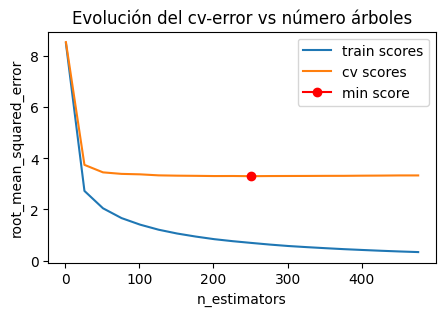

```python
# Validación empleando k-cross-validation y neg_root_mean_squared_error
# ==============================================================================
train_scores = []
cv_scores    = []

# Valores evaluados
max_iter_range = range(1, 500, 25)

# Bucle para entrenar un modelo con cada valor de n_estimators y extraer su error
# de entrenamiento y de k-cross-validation.
for max_iter in max_iter_range:

    modelo = HistGradientBoostingRegressor(
                max_iter     = max_iter,
                random_state = 123
             )

    # Error de train
    modelo.fit(X_train, y_train)
    predicciones = modelo.predict(X = X_train)
    rmse = mean_squared_error(
            y_true  = y_train,
            y_pred  = predicciones,
            squared = False
           )
    train_scores.append(rmse)

    # Error de validación cruzada
    scores = cross_val_score(
                estimator = modelo,
                X         = X_train,
                y         = y_train,
                scoring   = 'neg_root_mean_squared_error',
                cv        = 5,
                n_jobs    = multiprocessing.cpu_count() - 1,
             )
    # Se agregan los scores de cross_val_score() y se pasa a positivo
    cv_scores.append(-1*scores.mean())

# Gráfico con la evolución de los errores
fig, ax = plt.subplots(figsize=(5, 3))
ax.plot(max_iter_range, train_scores, label="train scores")
ax.plot(max_iter_range, cv_scores, label="cv scores")
ax.plot(max_iter_range[np.argmin(cv_scores)], min(cv_scores),
        marker='o', color = "red", label="min score")
ax.set_ylabel("root_mean_squared_error")
ax.set_xlabel("n_estimators")
ax.set_title("Evolución del cv-error vs número árboles")
plt.legend();
print(f"Valor óptimo de n_estimators: {max_iter_range[np.argmin(cv_scores)]}")
```

Los valores estimados por validación cruzada muestran que, a partir de los 50 árboles, el error del modelo se estabiliza, consiguiendo un mínimo con 251 árboles.

#### Learning rate

Junto con el número de árboles, el `learning_rate` es el hiperparámetro más importantes en *Gradient Boosting*, ya que es el que permite controlar cómo de rápido aprende el modelo y con ello el riesgo de llegar al *overfitting*. Estos dos hiperparámetros son interdependientes, cuanto menor es el *learning rate*, más árboles se necesitan para alcanzar buenos resultados pero menor es el riesgo de *overfitting*.

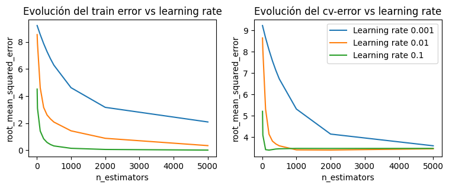

```python
# Validación empleando k-cross-validation y neg_root_mean_squared_error
# ==============================================================================
resultados = {}

# Valores evaluados
learning_rates_grid = [0.001, 0.01, 0.1]
max_iter_grid   = [10, 20, 100, 200, 300, 400, 500, 1000, 2000, 5000]


# Bucle para entrenar un modelo con cada combinacion de  learning_rate y n_estimator
# y extraer su error de entrenamiento y k-cross-validation.
for learning_rate in learning_rates_grid:
    train_scores = []
    cv_scores    = []

    for n_estimator in max_iter_grid:

        modelo = HistGradientBoostingRegressor(
                    max_iter      =  n_estimator,
                    learning_rate = learning_rate,
                    random_state  = 123
                 )

        # Error de train
        modelo.fit(X_train, y_train)
        predicciones = modelo.predict(X = X_train)
        rmse = mean_squared_error(
                y_true  = y_train,
                y_pred  = predicciones,
                squared = False
               )
        train_scores.append(rmse)

        # Error de validación cruzada
        scores = cross_val_score(
                    estimator = modelo,
                    X         = X_train,
                    y         = y_train,
                    scoring   = 'neg_root_mean_squared_error',
                    cv        = 3,
                    n_jobs    = multiprocessing.cpu_count() - 1
                 )
        # Se agregan los scores de cross_val_score() y se pasa a positivo
        cv_scores.append(-1*scores.mean())

    resultados[learning_rate] = {'train_scores': train_scores, 'cv_scores': cv_scores}

# Gráfico con la evolución de los errores de entrenamiento
fig, axs = plt.subplots(nrows=1, ncols=2, figsize=(9, 3))

for key, value in resultados.items():
    axs[0].plot(max_iter_grid, value['train_scores'], label=f"Learning rate {key}")
    axs[0].set_ylabel("root_mean_squared_error")
    axs[0].set_xlabel("n_estimators")
    axs[0].set_title("Evolución del train error vs learning rate")

    axs[1].plot(max_iter_grid, value['cv_scores'], label=f"Learning rate {key}")
    axs[1].set_ylabel("root_mean_squared_error")
    axs[1].set_xlabel("n_estimators")
    axs[1].set_title("Evolución del cv-error vs learning rate")
    plt.legend();
```

Puede observarse que, cuanto mayor es el valor del *learning rate*, más rápido aprende el modelo pero antes puede aparecer el *overfitting*. En este caso, los errores estimados por validación cruzada indican que, el mejor modelo se consigue con un *learning rate* de 0.1.

#### Max depth

La profundidad de los árboles (`max_depth`) en los modelos *Gradient Boosting* suele ser un valor muy bajo, haciendo así que cada árbol solo pueda aprender un pequeña parte de la relación entre predictores y variable respuesta (*weak learner*).

```
Valor óptimo de max_depth: 5
```

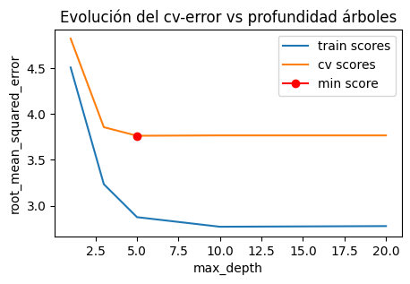

```python
# Validación empleando k-cross-validation y neg_root_mean_squared_error
# ==============================================================================
train_scores = []
cv_scores    = []

# Valores evaluados
max_depths = [1, 3, 5, 10, 20]

# Bucle para entrenar un modelo con cada valor de max_depth y extraer su error
# de entrenamiento y de k-cross-validation.
for max_depth in max_depths:

    modelo = HistGradientBoostingRegressor(
                max_iter     = 25,
                max_depth    = max_depth,
                random_state = 123
             )

    # Error de train
    modelo.fit(X_train, y_train)
    predicciones = modelo.predict(X = X_train)
    rmse = mean_squared_error(
            y_true  = y_train,
            y_pred  = predicciones,
            squared = False
           )
    train_scores.append(rmse)

    # Error de validación cruzada
    scores = cross_val_score(
                estimator = modelo,
                X         = X_train,
                y         = y_train,
                scoring   = 'neg_root_mean_squared_error',
                cv        = 5,
                n_jobs    = multiprocessing.cpu_count() - 1
             )
    # Se agregan los scores de cross_val_score() y se pasa a positivo
    cv_scores.append(-1*scores.mean())

# Gráfico con la evolución de los errores
fig, ax = plt.subplots(figsize=(5, 3))
ax.plot(max_depths, train_scores, label="train scores")
ax.plot(max_depths, cv_scores, label="cv scores")
ax.plot(max_depths[np.argmin(cv_scores)], min(cv_scores),
        marker='o', color = "red", label="min score")
ax.set_ylabel("root_mean_squared_error")
ax.set_xlabel("max_depth")
ax.set_title("Evolución del cv-error vs profundidad árboles")
plt.legend();
print(f"Valor óptimo de max_depth: {max_depths[np.argmin(cv_scores)]}")
```

### Grid search

Aunque el análisis individual de los hiperparámetros es útil para entender su impacto en el modelo e identificar rangos de interés, la búsqueda final no debe hacerse de forma secuencial, ya que cada hiperparámetro interacciona con los demás. Es preferible recurrir a *grid search* o *random search* para analizar varias combinaciones de hiperparámetros. Puede encontrarse más información sobre las estrategias de búsqueda en [**Machine learning con Python y Scikit-learn**](https://www.cienciadedatos.net/documentos/py06_machine_learning_python_scikitlearn.html).

Cuando los recursos computacionales (o tiempo) son limitados, es aconsejable seguir una de las siguientes estrategias para identificar los hiperparámetros óptimos de un modelo *Gradient Boosting*:

- Fijar el número de árboles y optimizar el *learning rate*.
- Fijar el *learning rate* y añadir tantos árboles como sea necesario pero activando la parada temprana para evitar *overfitting*.

Una vez identificados los valores de estos hiperparámetros, se refinan el resto.

**Tip**

Cuando los recursos computacionales (o tiempo) son limitados, es aconsejable seguir una de las siguientes estrategias para identificar los hiperparámetros óptimos de un modelo *Gradient Boosting*:

- Fijar el número de árboles y optimizar el *learning rate*.
- Fijar el *learning rate* y añadir tantos árboles como sea necesario pero activando la parada temprana para evitar *overfitting*.

Una vez identificados los valores de estos hiperparámetros, se refinan el resto.

#### Grid Search basado en validación cruzada

En la siguiente búsqueda de hiperparámetros, se emplea la estrategia de no incluir el número de árboles como hiperparámetro en el *grid*. En su lugar, se utiliza por defecto un número muy elevado y se activa la parada temprana.

En las implementaciones nativas de *scikit-learn* (`GradientBoosting` y `HistGradientBoosting`), el conjunto de validación para la parada temprana se extrae automáticamente de los datos de entrenamiento utilizados en cada ajuste, por lo que puede integrarse directamente en el `GridSearchCV()` o `RandomizedSearchCV()`.

```python
# Grid de hiperparámetros evaluados
# ==============================================================================
param_grid = {'loss'             : ['squared_error', 'absolute_error'],
              'learning_rate'    : [0.001, 0.01, 0.1],
              'max_depth'        : [3, 5, 10, 20],
              'l2_regularization': [0, 1, 10]
             }

# Búsqueda por grid search con validación cruzada
# ==============================================================================
grid = GridSearchCV(
        estimator  = HistGradientBoostingRegressor(
                        max_iter            = 1000,
                        random_state        = 123,
                        # Activación de la parada temprana
                        early_stopping      = True,
                        validation_fraction = 0.1,
                        n_iter_no_change    = 10,
                        tol                 = 1e-7,
                        scoring             = 'loss',
                    ),
        param_grid = param_grid,
        scoring    = 'neg_root_mean_squared_error',
        n_jobs     = multiprocessing.cpu_count() - 1,
        cv         = RepeatedKFold(n_splits=3, n_repeats=1, random_state=123),
        refit      = True,
        verbose    = 0,
        return_train_score = True
       )

grid.fit(X = X_train, y = y_train)

# Resultados
# ==============================================================================
resultados = pd.DataFrame(grid.cv_results_)
resultados.filter(regex = '(param.*|mean_t|std_t)') \
    .drop(columns = 'params') \
    .sort_values('mean_test_score', ascending = False) \
    .head(4)
```

|  | param_l2_regularization | param_learning_rate | param_loss | param_max_depth | mean_test_score | std_test_score | mean_train_score | std_train_score |
| --- | --- | --- | --- | --- | --- | --- | --- | --- |
| 42 | 1 | 0.1 | squared_error | 10 | -3.669431 | 0.448214 | -2.337653 | 0.595595 |
| 43 | 1 | 0.1 | squared_error | 20 | -3.669431 | 0.448214 | -2.337653 | 0.595595 |
| 17 | 0 | 0.1 | squared_error | 5 | -3.716610 | 0.384398 | -2.406267 | 0.574598 |
| 19 | 0 | 0.1 | squared_error | 20 | -3.771660 | 0.454215 | -2.478086 | 0.451284 |

```python
# Mejores hiperparámetros por validación cruzada
# ==============================================================================
print("----------------------------------------")
print("Mejores hiperparámetros encontrados (cv)")
print("----------------------------------------")
print(grid.best_params_, ":", grid.best_score_, grid.scoring)
```

```
----------------------------------------
Mejores hiperparámetros encontrados (cv)
----------------------------------------
{'l2_regularization': 1, 'learning_rate': 0.1, 'loss': 'squared_error', 'max_depth': 10} : -3.6694305864579335 neg_root_mean_squared_error
```

**⚠ Warning**

Aunque se ha indicado que `` n_estimator = 1000` ``, debido a la activación de la parada temprana, el entrenamiento puede haberse detenido antes.

```python
# Número de árboles del modelo final (early stopping)
# ==============================================================================
print(f"Número de árboles del modelo: {grid.best_estimator_.n_iter_}")
```

```
Número de árboles del modelo: 50
```

Una vez identificados los mejores hiperparámetros, se reentrena el modelo indicando los valores óptimos en sus argumentos. Si en el `GridSearchCV()` se indica `refit=True`, este reentrenamiento se hace automáticamente y el modelo resultante se encuentra almacenado en `.best_estimator_`.

```python
# Error de test del modelo final
# ==============================================================================
modelo_final = grid.best_estimator_
predicciones = modelo_final.predict(X = X_test)
rmse = mean_squared_error(
        y_true  = y_test,
        y_pred  = predicciones,
        squared = False
       )
print(f"El error (rmse) de test es: {rmse}")
```

```
El error (rmse) de test es: 4.125497064570422
```

Tras optimizar los hiperparámetros, se consigue reducir el error *rmse* del modelo de 5.2 a 4.1. Las predicciones del modelo final se alejan en promedio 4.1 unidades (4100 dólares) del valor real.

### Importancia de predictores

`HistGradientBoostingRegressor` ya no incorpora la importancia de los predictores basándose en la pureza de nodos por las evidencias de que esta forma de calcular la importancia está altamente influenciada por el número de predictores utilizados. En su lugar, se recomienda el uso del método de permutación.

```python
importancia = permutation_importance(
                estimator    = modelo_final,
                X            = X_train,
                y            = y_train,
                n_repeats    = 5,
                scoring      = 'neg_root_mean_squared_error',
                n_jobs       = multiprocessing.cpu_count() - 1,
                random_state = 123
             )

# Se almacenan los resultados (media y desviación) en un dataframe
df_importancia = pd.DataFrame(
                    {k: importancia[k] for k in ['importances_mean', 'importances_std']}
                 )
df_importancia['feature'] = X_train.columns
df_importancia.sort_values('importances_mean', ascending=False)
```

|  | importances_mean | importances_std | feature |
| --- | --- | --- | --- |
| 11 | 5.446604 | 0.288384 | LSTAT |
| 5 | 4.903891 | 0.176809 | RM |
| 7 | 0.856145 | 0.080632 | DIS |
| 4 | 0.847798 | 0.065242 | NOX |
| 0 | 0.465227 | 0.030585 | CRIM |
| 6 | 0.335038 | 0.046341 | AGE |
| 10 | 0.308566 | 0.026022 | PTRATIO |
| 9 | 0.230401 | 0.033951 | TAX |
| 2 | 0.155159 | 0.013061 | INDUS |
| 8 | 0.093236 | 0.014850 | RAD |
| 1 | 0.002374 | 0.000775 | ZN |
| 3 | 0.000000 | 0.000000 | CHAS |

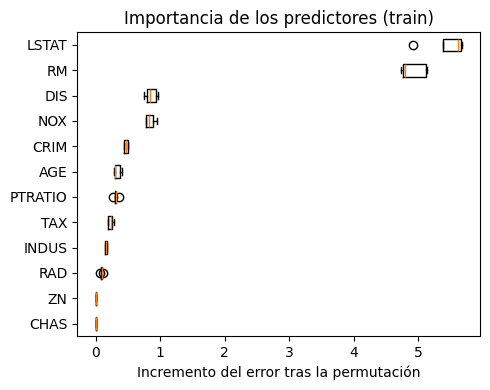

```python
# Gráfico
fig, ax = plt.subplots(figsize=(5, 4))
sorted_idx = importancia.importances_mean.argsort()
ax.boxplot(
        importancia.importances[sorted_idx].T,
        vert   = False,
        labels = datos.drop(columns = "MEDV").columns[sorted_idx]
)
ax.set_title('Importancia de los predictores (train)')
ax.set_xlabel('Incremento del error tras la permutación')
fig.tight_layout();
```

## XGBoost y LighGBM

### XGBoost

A diferencia de las implementaciones nativas de *scikit-learn*, en *XGBoost* y *LightGBM*, el conjunto de validación para la parada temprana, no se extrae automáticamente. Para poder integrar la parada temprana con el `GridSearchCV()` o `RandomizedSearchCV()` y que no haya observaciones que participan en ambos procesos, se tiene que separar manualmente un conjunto de validación del de entrenamiento.

```python
# Instalación XGBoost: pip install xgboost
from xgboost import XGBRegressor
```

```python
# Grid de hiperparámetros evaluados
# ==============================================================================
param_grid = {'max_depth'        : [None, 1, 3, 5, 10, 20],
              'subsample'        : [0.5, 1],
              'learning_rate'    : [0.001, 0.01, 0.1],
              'booster'          : ['gbtree']
             }


# Crear conjunto de validación
# ==============================================================================
np.random.seed(123)
idx_validacion = np.random.choice(
                    X_train.shape[0],
                    size=int(X_train.shape[0]*0.1), #10% de los datos de entrenamiento
                    replace=False
                 )

X_val = X_train.iloc[idx_validacion, :].copy()
y_val = y_train.iloc[idx_validacion].copy()

X_train_grid = X_train.reset_index(drop = True).drop(idx_validacion, axis = 0).copy()
y_train_grid = y_train.reset_index(drop = True).drop(idx_validacion, axis = 0).copy()

# XGBoost necesita pasar los paramétros específicos del entrenamiento al llamar
# al método .fit()
fit_params = {
              "eval_set": [(X_val, y_val)],
              "verbose": False
             }

# Búsqueda por grid search con validación cruzada
# ==============================================================================
grid = GridSearchCV(
        estimator  = XGBRegressor(
                        n_estimators          = 1000,
                        early_stopping_rounds = 5,
                        eval_metric           = "rmse",
                        random_state          = 123
                    ),
        param_grid = param_grid,
        scoring    = 'neg_root_mean_squared_error',
        n_jobs     = multiprocessing.cpu_count() - 1,
        cv         = RepeatedKFold(n_splits=3, n_repeats=1, random_state=123),
        refit      = True,
        verbose    = 0,
        return_train_score = True
       )

grid.fit(X = X_train_grid, y = y_train_grid, **fit_params)

# Resultados
# ==============================================================================
resultados = pd.DataFrame(grid.cv_results_)
resultados.filter(regex = '(param.*|mean_t|std_t)') \
    .drop(columns = 'params') \
    .sort_values('mean_test_score', ascending = False) \
    .head(4)
```

|  | param_booster | param_learning_rate | param_max_depth | param_subsample | mean_test_score | std_test_score | mean_train_score | std_train_score |
| --- | --- | --- | --- | --- | --- | --- | --- | --- |
| 30 | gbtree | 0.1 | 5 | 0.5 | -3.571931 | 0.719950 | -1.342165 | 0.526435 |
| 24 | gbtree | 0.1 | None | 0.5 | -3.582584 | 0.826411 | -1.291940 | 0.178487 |
| 28 | gbtree | 0.1 | 3 | 0.5 | -3.596407 | 0.804534 | -2.075729 | 0.431105 |
| 22 | gbtree | 0.01 | 20 | 0.5 | -3.604234 | 0.790147 | -1.429488 | 0.664169 |

```python
# Mejores hiperparámetros por validación cruzada
# ==============================================================================
print("----------------------------------------")
print("Mejores hiperparámetros encontrados (cv)")
print("----------------------------------------")
print(grid.best_params_, ":", grid.best_score_, grid.scoring)

# Número de árboles del modelo final (early stopping)
# ==============================================================================
n_arboles_incluidos = len(grid.best_estimator_.get_booster().get_dump())
print(f"Número de árboles incluidos en el modelo: {n_arboles_incluidos}")
```

```
----------------------------------------
Mejores hiperparámetros encontrados (cv)
----------------------------------------
{'booster': 'gbtree', 'learning_rate': 0.1, 'max_depth': 5, 'subsample': 0.5} : -3.571931478990358 neg_root_mean_squared_error
Número de árboles incluidos en el modelo: 46
```

```python
# Error de test del modelo final
# ==============================================================================
modelo_final = grid.best_estimator_
predicciones = modelo_final.predict(X_test)
rmse = mean_squared_error(
        y_true  = y_test,
        y_pred  = predicciones,
        squared = False
       )
print(f"El error (rmse) de test es: {rmse}")
```

```
El error (rmse) de test es: 3.7236512493927427
```